# Tutorial 8.1: Multiple regression on the fish tank dataset

As an exercise on multiple regression, we will analyse the fish tank dataset.

# 1 Fish tank dataset

In this experiments 96 fish (dojofish, goldfish and zebrafish) were placed separately in a tank with two liters of water and a certain dose (in mg) of a certain poison EI-43,064. The resistance of the fish a against the poison was measured as the amount of minutes the fish survived upon adding the poison (Surv_time, in minutes). Additionally, the weightt of each fish was measured.

# 2 Goal

In this tutorial, we will study the association between dose and survival time, while correcting for weight and species, by using a multiple regression model.

Read the required libraries

```r
library(GGally)
library(tidyverse)
library(car)
```

# 3 Import the data

```r
poison <- read_csv("https://raw.githubusercontent.com/GTPB/PSLS20/master/data/poison.csv")
head(poison)
```

```
## # A tibble: 6 x 4
##   species Weight  Dose Surv_time
##     <dbl>  <dbl> <dbl>     <dbl>
## 1       0   1.88   1        3.46
## 2       2   1.73   1.1      2.11
## 3       1   2.83   1.2     11.4
## 4       2   1.75   1.3      1.82
## 5       0   2.11   1.4      3.28
## 6       0   1.85   1.5      2.96
```

# 4 Data tidying

We can see a couple of things in the data that can be improved upon:

1. Capitalize the fist column name
2. Set the Species column as a factor
3. Change the speciec factor levels from 0, 1 and 2 to Dojofish, Goldfish and Zebrafish. Hint: use the fct_recode function.
4. Add the variable log.Surv_time: we already saw in previous tutorials that this transfromation is required to obtain normally distributed data.

```r
poison <- poison %>%
  rename("Species" = "species") %>%
  mutate(Species = as.factor(Species)) %>%
  mutate(Species = fct_recode(Species, Dojofish = "0", Goldfish = "1", Zebrafish = "2")) %>%
  mutate(log.Surv_time = log(Surv_time))

poison
```

```
## # A tibble: 96 x 5
##    Species   Weight  Dose Surv_time log.Surv_time
##    <fct>      <dbl> <dbl>     <dbl>         <dbl>
##  1 Dojofish    1.88   1        3.46         1.24
##  2 Zebrafish   1.73   1.1      2.11         0.747
##  3 Goldfish    2.83   1.2     11.4          2.44
##  4 Zebrafish   1.75   1.3      1.82         0.599
##  5 Dojofish    2.11   1.4      3.28         1.19
##  6 Dojofish    1.85   1.5      2.96         1.08
##  7 Zebrafish   1.22   1.6      1.85         0.615
##  8 Goldfish    2.05   1.7      8.05         2.09
##  9 Dojofish    1.80   1.8      1.65         0.504
## 10 Goldfish    2.50   1.9      7.95         2.07
## # … with 86 more rows
```

# 5 Data exploration

In a previous tutorial, we already studied the effect of dose on (the logarithm of) suvival time. There, we did not account for the fact that fish of the same species and/or fish of similar weight will probably reacht similarly to the poison.

When we expect the data more closely, we see that these factors do indeed matter.

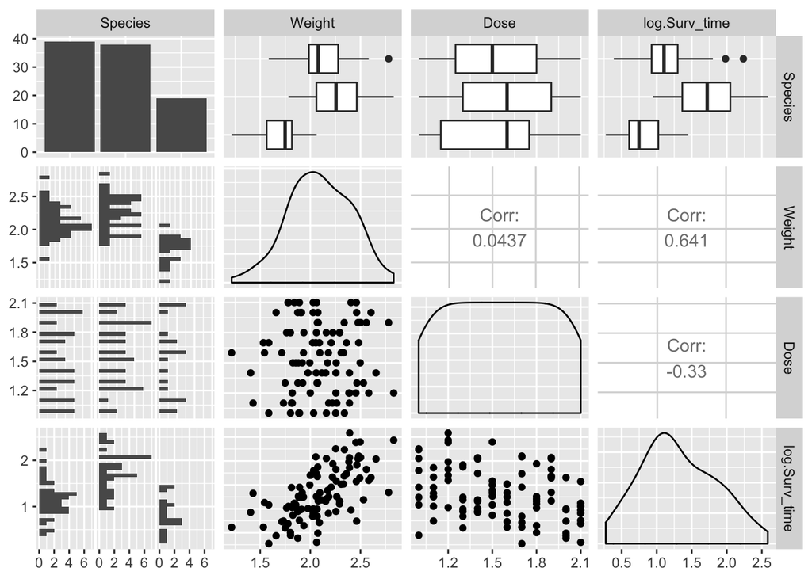

```r
poison %>% dplyr::select(Species,Weight,Dose,log.Surv_time) %>% ggpairs()
```

Some additional visualizations:

- Plot the log survival time in function of weigth. Add species as a color.

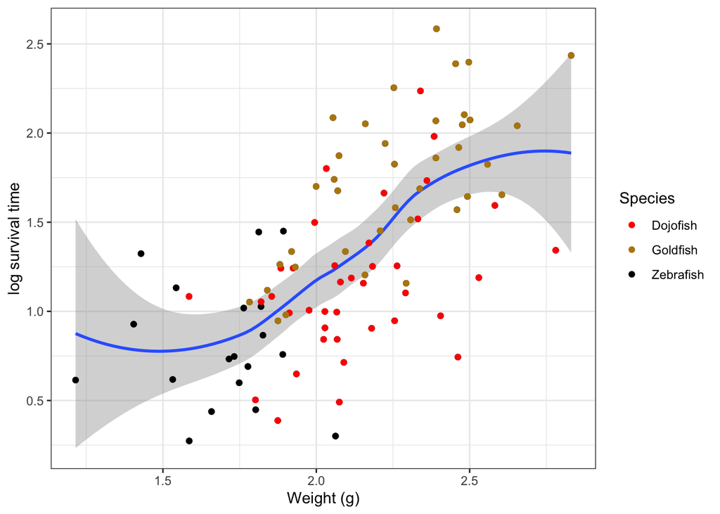

```r
poison %>%
  ggplot(aes(x=Weight,y=log.Surv_time)) +
  geom_point() +
  stat_smooth(method = "loess") +
  ylab("log survival time") +
  xlab("Weight (g)") +
  geom_point(aes(col=Species)) +
  scale_color_manual(values = c("red","darkgoldenrod","black")) +
  theme_bw()
```

We observe a very strong relationship between weight and log survival time. The weigth is different for different species.

- Plot the fish weights in function of dose

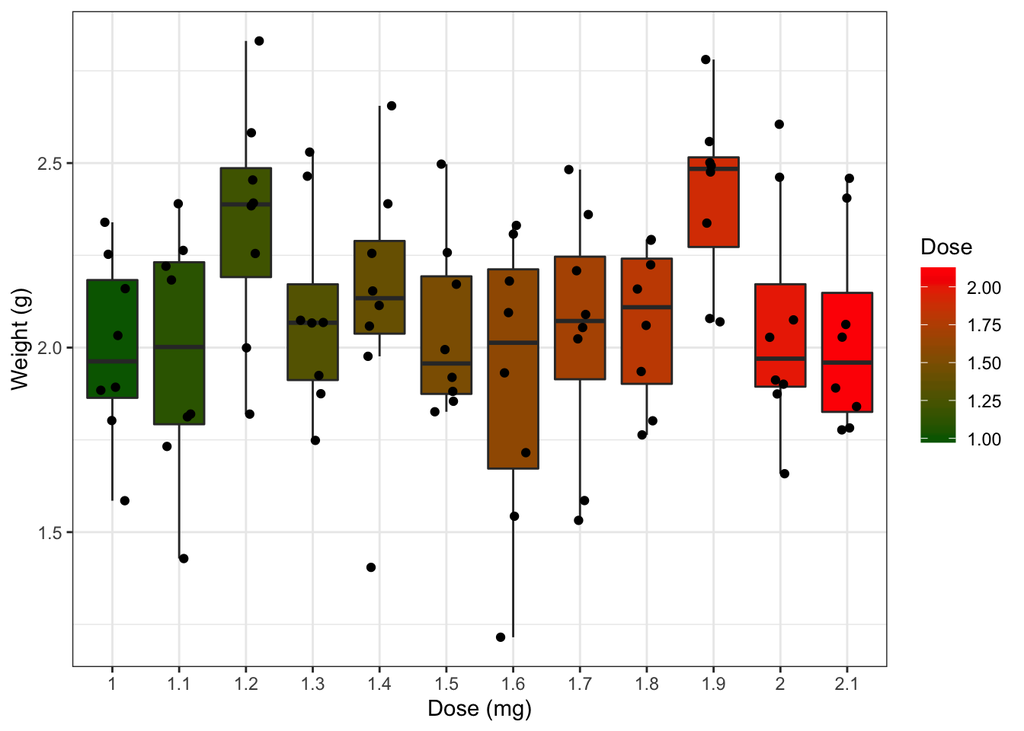

```r
poison %>%
  ggplot(aes(x=as.factor(Dose),y=Weight,fill=Dose)) +
  geom_boxplot(outlier.shape=NA) +
  geom_jitter(width = 0.2) +
  scale_fill_gradient(low = "darkgreen", high = "red") +
  ylab("Weight (g)") +
  xlab("Dose (mg)") +
  theme_bw()
```

We see that, probably by chance, some specific dosages were administered to fish with slightly higher (e.g. dose 1.9 mg) or lower weights.

- Plot the log of survival time in function of dose.

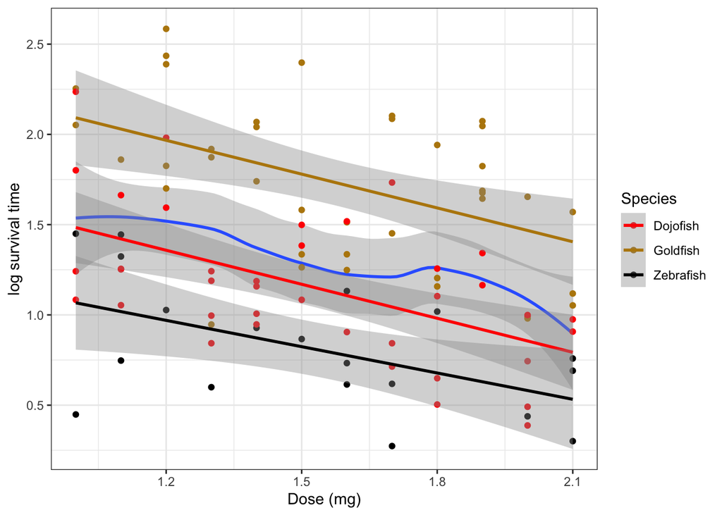

```r
poison %>%
  ggplot(aes(x=Dose,y=log.Surv_time)) +
  stat_smooth(method = "loess") +
  ylab("log survival time") +
  xlab("Dose (mg)") +
  geom_point(aes(col=Species)) +
  scale_color_manual(values = c("red","darkgoldenrod","black")) +
  theme_bw() +
  geom_smooth(aes(group=Species,col=Species), method='lm')
```

There is a clear linear relationship between dose and log survival time, but especially the intercept of the linear model will be different for different species.

- Plot the relationship between log survival time and species.

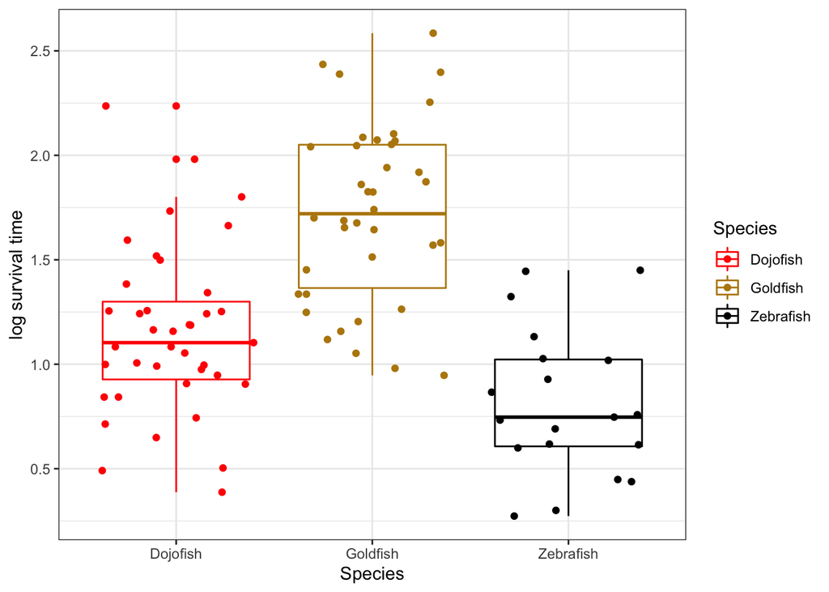

```r
poison %>%
  ggplot(aes(x=Species,y=log.Surv_time,color=Species)) +
  geom_boxplot() +
  geom_jitter() +
  ylab("log survival time") +
  scale_color_manual(values = c("red","darkgoldenrod","black")) +
  theme_bw()
```

The log survival time is different for different species.

The researchers assume, based on the data exploration, that the dose effect on survival varies between different species. As such, a good model should have an interaction effect between dose and species. We will also include an interaction between weight and species.

# 6 Analysis

## 6.1 Assess full model with main and interaction effects

$$y_i=\beta_0+\beta_d x_{id} + \beta_w x_{iw} +\beta_{sg} x_{isg} +\beta_{sz} x_{isz} + \beta_{d-sg} x_{id}x_{isg} + \beta_{d-sz} x_{id}x_{isz} + \beta_{w-sg} x_{iw}x_{isg} + \beta_{w-sz} x_{iw}x_{isz} + \epsilon_i,$$

with $x_{isg}$ and $x_{isz}$ the dummy variables pointing at goldfish and zebrafish, respectively. Dojofish are the reference class, i.e. when $x_{isg}=0$ en $x_{isz}=0$.

We assume $\epsilon_i \text{ i.i.d. } N(0,\sigma^2)$.

We will predict the dose response for each species.

$$\begin{array}{ll}
\text{dojofish } (x_{isg}=0\text{ and }x_{isz}=0):&E[y\vert \text{dojofish}]=\beta_0+\beta_d x_{id} + \beta_w x_{iw}\\
\text{goldfish } (x_{isg}=1\text{ and }x_{isz}=0):&E[y\vert \text{goldfish}]=\beta_0+\beta_{sg}+(\beta_d+ \beta_{d-sa}) x_{id} + (\beta_w+\beta_{w-sg}) x_{iw}\\
\text{zebrafish } (x_{isg}=0\text{ and }x_{isz}=1):&E[y\vert \text{zebrafish}]=\beta_0+\beta_{sz}+(\beta_d+ \beta_{d-sz}) x_{id} + (\beta_w+\beta_{w-sz}) x_{iw}\\
\end{array}$$

- The species main effect makes sure that each species will have its own intercept in the model. ($\beta_0$, $\beta_0 + \beta_{sg}$, $\beta_0+\beta_{sz}$)
- The interaction between species and dose ensures that the dose effect (slope) can be different between different species. ($\beta_d$, $\beta_d+\beta_{d-sg}$, $\beta_d+\beta_{d-sz}$)
- The interaction between species and weight makes sure that the weigth effect (slope) can be different for different species. ($\beta_w$, $\beta_w+\beta_{w-sg}$, $\beta_w+\beta_{w-sz}$

Note: if we would not use the interaction terms, but still wanted to model the data correctly, we could fit a separate model for every species. The advantage of modelling the data for all species together, is that we are using all of the data to estimate the residual variances.

Let us now fit the full multiple regression model:

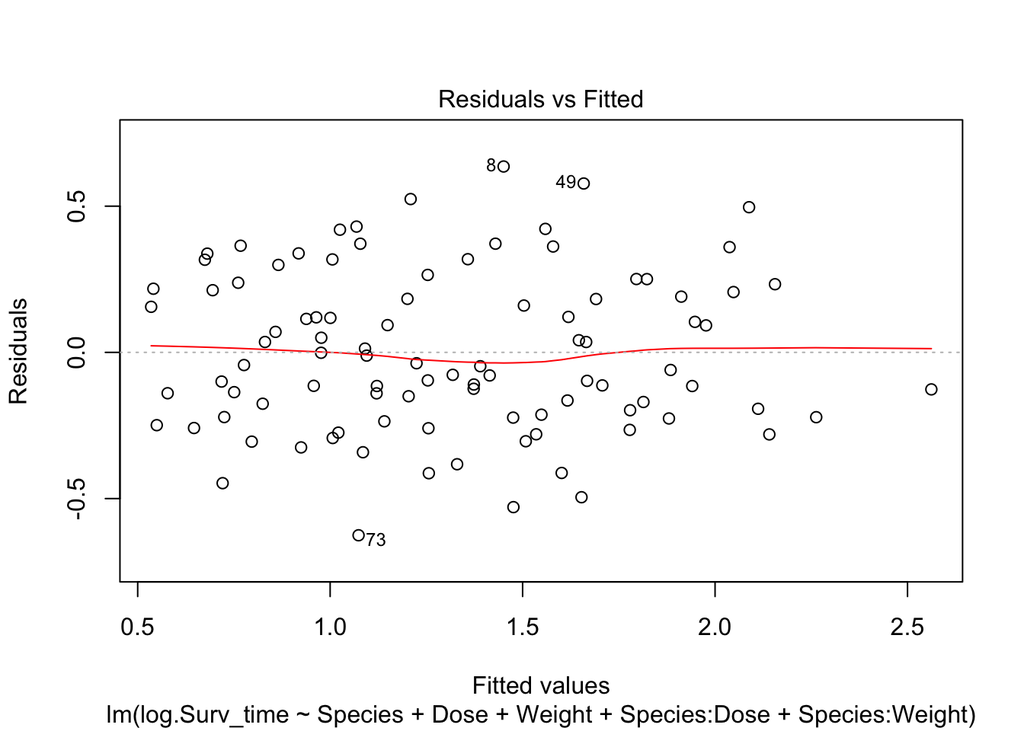

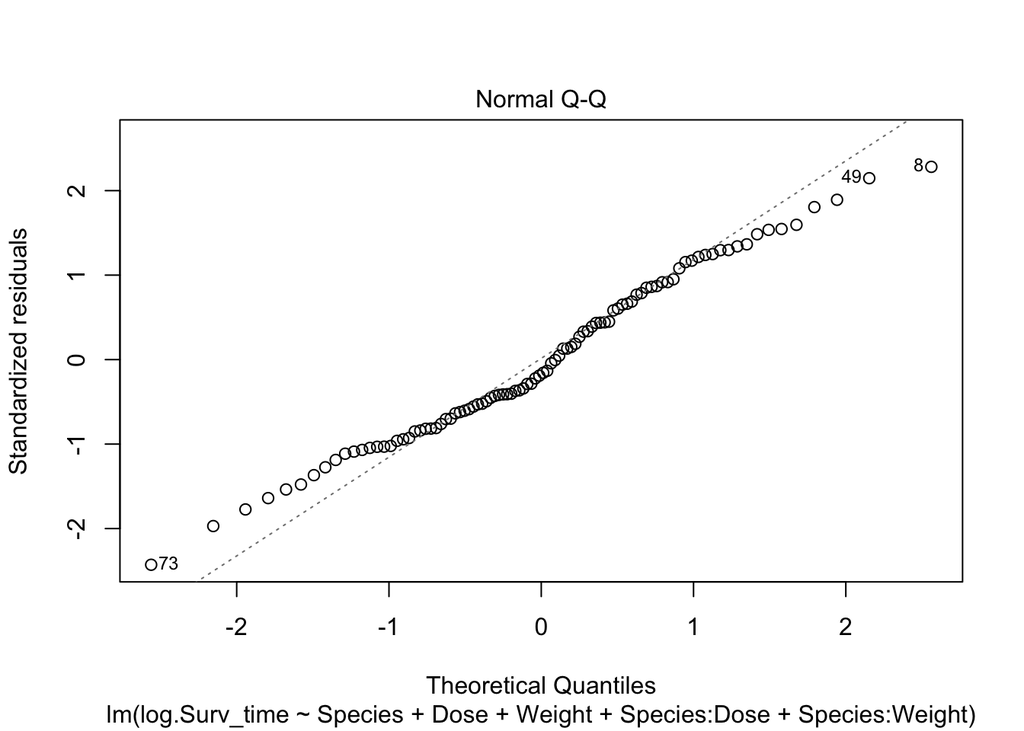

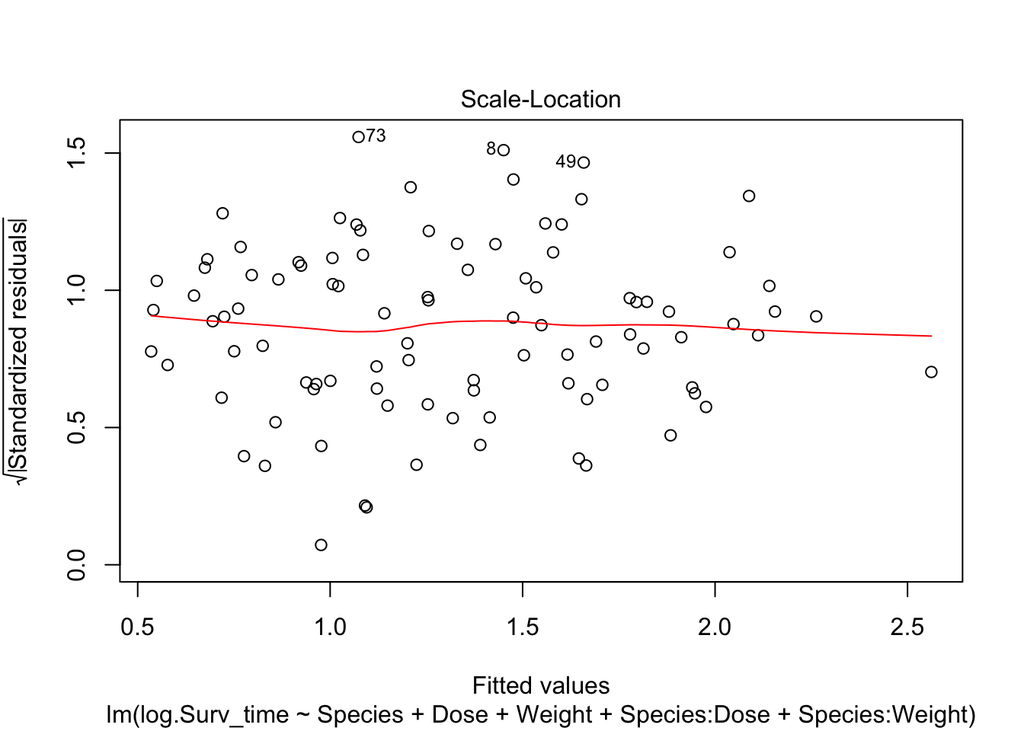

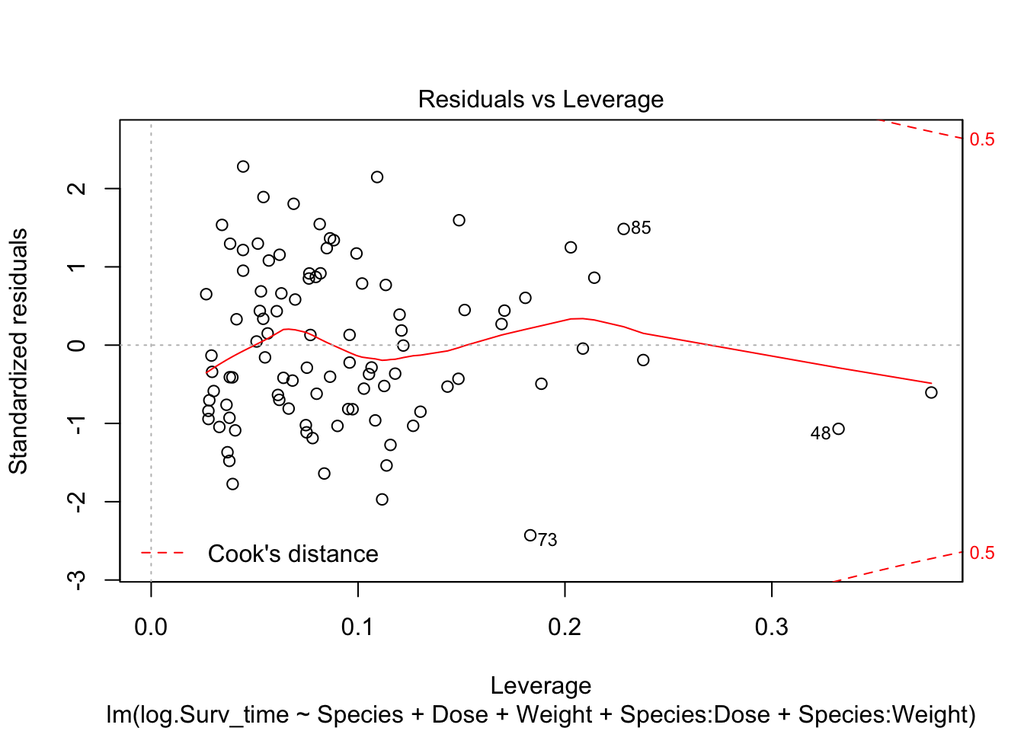

```r
lm_full <- lm(log.Surv_time~ Species + Dose + Weight + Species:Dose + Species:Weight, data=poison)
plot(lm_full)
```

### 6.1.1 Assumptions

List assumptions:

1. The observations are independent of each other
2. Linearity between the response and predictor variable
3. The residues of the model must be normally distributed
4. Homoscedasticity of the data

Asses:

1. The first assumption is **met**. As discussed a previous tutorial, there are patterns of relatedness in the data: We expect that fish of the same species have a more similar response to the poison as compared to fish of another species. Equivalently, we expect that fish of the same weight have a more similar response to the poison as compared to fish of different weight.

**Our model now specifically accounts for this**. We do not expect that there are inducing additional dependcies in the data.

2. The linearity assumption is **met**.
3. The normality assumption is **met**. There is a small deviation from normality, but given the relatively large dataset (96 observations) we do not expect this to cause major problems. In addition, we have a relativwly large dataset, so we could start relying on the central limit theorem).
4. The homoscedasticity assumption is **met**.

### 6.1.2 Model parameters

```r
Anova(lm_full, type = "III") ## type three in presence of important interactions
```

```
## Anova Table (Type III tests)
##
## Response: log.Surv_time
##                Sum Sq Df F value    Pr(>F)
## (Intercept)    0.1343  1  1.6538  0.201855
## Species        0.2309  2  1.4213  0.246945
## Dose           2.1007  1 25.8662 2.081e-06 ***
## Weight         1.2136  1 14.9435  0.000213 ***
## Species:Dose   0.0599  2  0.3686  0.692803
## Species:Weight 0.6027  2  3.7103  0.028423 *
## Residuals      7.0658 87
## ---
## Signif. codes:  0 '***' 0.001 '**' 0.01 '*' 0.05 '.' 0.1 ' ' 1
```

```r
summary(lm_full)
```

```
##
## Call:
## lm(formula = log.Surv_time ~ Species + Dose + Weight + Species:Dose +
##     Species:Weight, data = poison)
##
## Residuals:
##      Min       1Q   Median       3Q      Max
## -0.62547 -0.21517 -0.04538  0.21384  0.63564
##
## Coefficients:
##                         Estimate Std. Error t value Pr(>|t|)
## (Intercept)               0.5749     0.4471   1.286 0.201855
## SpeciesGoldfish          -0.4090     0.6634  -0.616 0.539219
## SpeciesZebrafish          0.8956     0.7520   1.191 0.236924
## Dose                     -0.6648     0.1307  -5.086 2.08e-06 ***
## Weight                    0.7474     0.1933   3.866 0.000213 ***
## SpeciesGoldfish:Dose      0.1171     0.1944   0.602 0.548640
## SpeciesZebrafish:Dose     0.1761     0.2196   0.802 0.424863
## SpeciesGoldfish:Weight    0.3311     0.2660   1.245 0.216506
## SpeciesZebrafish:Weight  -0.6964     0.3861  -1.804 0.074754 .
## ---
## Signif. codes:  0 '***' 0.001 '**' 0.01 '*' 0.05 '.' 0.1 ' ' 1
##
## Residual standard error: 0.285 on 87 degrees of freedom
## Multiple R-squared:  0.7429, Adjusted R-squared:  0.7192
## F-statistic: 31.42 on 8 and 87 DF,  p-value: < 2.2e-16
```

We clearly see that the interaction effect between species and dose, which ensures that the dose effect (slope) can be different between different species, does not have a significant contribution to the linear regression model after correcting for the other variables in that model. As such, this interaction effect could be omitted from the model.

## 6.2 Reduced model

```r
lm_red <- lm(log.Surv_time~ Species + Dose + Weight + Species:Weight, data=poison)

Anova_red <- Anova(lm_red, type="III")
Anova_red
```

```
## Anova Table (Type III tests)
##
## Response: log.Surv_time
##                Sum Sq Df F value    Pr(>F)
## (Intercept)    0.0976  1  1.2189 0.2725612
## Species        0.3154  2  1.9700 0.1454937
## Dose           3.8388  1 47.9475 6.556e-10 ***
## Weight         1.1891  1 14.8523 0.0002191 ***
## Species:Weight 0.5815  2  3.6316 0.0304711 *
## Residuals      7.1256 89
## ---
## Signif. codes:  0 '***' 0.001 '**' 0.01 '*' 0.05 '.' 0.1 ' ' 1
```

```r
summary(lm_red)
```

```
##
## Call:
## lm(formula = log.Surv_time ~ Species + Dose + Weight + Species:Weight,
##     data = poison)
##
## Residuals:
##      Min       1Q   Median       3Q      Max
## -0.67734 -0.20174 -0.04116  0.20121  0.63897
##
## Coefficients:
##                         Estimate Std. Error t value Pr(>|t|)
## (Intercept)              0.46913    0.42493   1.104 0.272561
## SpeciesGoldfish         -0.23741    0.58157  -0.408 0.684099
## SpeciesZebrafish         1.11393    0.69699   1.598 0.113544
## Dose                    -0.58337    0.08425  -6.924 6.56e-10 ***
## Weight                   0.73868    0.19167   3.854 0.000219 ***
## SpeciesGoldfish:Weight   0.33575    0.26387   1.272 0.206550
## SpeciesZebrafish:Weight -0.66877    0.38158  -1.753 0.083108 .
## ---
## Signif. codes:  0 '***' 0.001 '**' 0.01 '*' 0.05 '.' 0.1 ' ' 1
##
## Residual standard error: 0.283 on 89 degrees of freedom
## Multiple R-squared:  0.7407, Adjusted R-squared:  0.7232
## F-statistic: 42.37 on 6 and 89 DF,  p-value: < 2.2e-16
```

Here, we see that the interaction term between weight and species remains significant in the model. As such, we will retain this interaction. This model will thus be our final model.

### 6.2.1 Main model

Before we interpret the output, we must first note that while the main effect for species does not appear significant in this model, this is merely beccause it’s effect is absorbed in the species:weight interaction term. Indeed, if we would work with a model only consisting of the three main effects, the species term would be extremely significant:

```r
lm_main <- lm(log.Surv_time ~ Dose + Weight + Species, data=poison)
Anova(lm_main, type = "III")
```

```
## Anova Table (Type III tests)
##
## Response: log.Surv_time
##             Sum Sq Df F value    Pr(>F)
## (Intercept) 0.1239  1  1.4624    0.2297
## Dose        4.1026  1 48.4406 5.118e-10 ***
## Weight      3.4457  1 40.6842 7.311e-09 ***
## Species     4.9579  2 29.2693 1.531e-10 ***
## Residuals   7.7071 91
## ---
## Signif. codes:  0 '***' 0.001 '**' 0.01 '*' 0.05 '.' 0.1 ' ' 1
```